# Emotion Detection - from Text Input

- **This time I use a better dataset "dair-ai/emotion"**

# 1. Imports

```python
import pandas as pd
import numpy as np
import matplotlib.pyplot as plt
import seaborn as sns
import neattext.functions as nfx
from sklearn.feature_extraction.text import CountVectorizer  # , TfidfVectorizer
from sklearn.model_selection import train_test_split
from sklearn.metrics import accuracy_score, classification_report,confusion_matrix, ConfusionMatrixDisplay
from sklearn.pipeline import Pipeline

# from sklearn.svm import SVC
# from sklearn.ensemble import RandomForestClassifier
from sklearn.linear_model import LogisticRegression
from sklearn.ensemble import RandomForestClassifier
from sklearn.naive_bayes import MultinomialNB
from sklearn.svm import SVC
# from sklearn.model_selection import GridSearchCV
# from xgboost import XGBClassifier

from pathlib import Path
cwd = Path.cwd()
# data_path = cwd / 'data'
# data_file = 'emotion_dataset_v2.csv'
# data_path_file = data_path / data_file
```

# 2. Load Dataset and EDA

```python
from datasets import load_dataset
emotions = load_dataset("dair-ai/emotion")
```

```python
emotions.set_format(type="pandas")
df=emotions["train"][:]
df.head()
```

|  | text | label |
| --- | --- | --- |
| 0 | i didnt feel humiliated | 0 |
| 1 | i can go from feeling so hopeless to so damned... | 0 |
| 2 | im grabbing a minute to post i feel greedy wrong | 3 |
| 3 | i am ever feeling nostalgic about the fireplac... | 2 |
| 4 | i am feeling grouchy | 3 |

```python
def label_int_to_str(row):
    return emotions["train"].features["label"].int2str(row)

df["label_name"] = df["label"].apply(label_int_to_str)
df.head()
```

|  | text | label | label_name |
| --- | --- | --- | --- |
| 0 | i didnt feel humiliated | 0 | sadness |
| 1 | i can go from feeling so hopeless to so damned... | 0 | sadness |
| 2 | im grabbing a minute to post i feel greedy wrong | 3 | anger |
| 3 | i am ever feeling nostalgic about the fireplac... | 2 | love |
| 4 | i am feeling grouchy | 3 | anger |

```python
print(df['label_name'].value_counts())
print('\nThere is class imbalance')
```

```
label_name
joy         5362
sadness     4666
anger       2159
fear        1937
love        1304
surprise     572
Name: count, dtype: int64

There is class imbalance
```

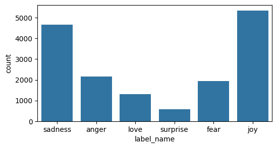

```
Visual View of classes and their counts
```

```python
plt.figure(figsize=(6,3))
sns.countplot(x='label_name', data=df)
plt.show()
print('Visual View of classes and their counts')
```

```python
moods = ['sadness', 'anger', 'love', 'surprise', 'fear', 'joy']
moods_int2str = {}
moods_str2int = {}
for mood in moods:
    fc = df['label_name'] == mood
    class_num = df.loc[fc, 'label'].values[0]
    moods_str2int[mood] = class_num
    moods_int2str[class_num] = mood

for k, v in moods_int2str.items():
    print(k, v)
print()
for k, v in moods_str2int.items():
    print(k, v)
print()
emotions_class_l = [moods_int2str.get(i) for i in range(len(moods_int2str.items()))]
print(emotions_class_l)
```

```
0 sadness
3 anger
2 love
5 surprise
4 fear
1 joy

sadness 0
anger 3
love 2
surprise 5
fear 4
joy 1

['sadness', 'joy', 'love', 'anger', 'fear', 'surprise']
```

# 5.0 Split the Dataset into Train and Test data

```python
df.columns
```

```
Index(['text', 'label', 'label_name'], dtype='object')
```

```python
X = df['text']
y = df['label']
print(X.shape, ' - ', y.shape )
```

```
(16000,)  -  (16000,)
```

```python
X_train, X_test, y_train, y_test = train_test_split(X, y, test_size=0.2, random_state=42, stratify=y)
print(X_train.shape, y_train.shape)
print(X_test.shape, y_test.shape)
```

```
(12800,) (12800,)
(3200,) (3200,)
```

# 6.0 Train

### 6.1 Baseline Models

```python
baseline_models = {}
models = {
    'logistic regression': LogisticRegression(random_state=42),
    'random forest': RandomForestClassifier(n_estimators=10, random_state=42),
    'multinomial naive bayes': MultinomialNB()
}
ml_pipeline = {}
for model_name, model in models.items():
    ml_pipeline[model_name] = Pipeline(steps=[('cv',CountVectorizer()), (model_name, model)])

from sklearn import set_config
set_config(display='diagram')
for model_name, pipeline in ml_pipeline.items():
    print(model_name)
    display(pipeline)
    print()
```

```
logistic regression
```

```
Pipeline(steps=[('cv', CountVectorizer()),
                ('logistic regression', LogisticRegression(random_state=42))])
```

```
random forest
```

```
Pipeline(steps=[('cv', CountVectorizer()),
                ('random forest',
                 RandomForestClassifier(n_estimators=10, random_state=42))])
```

```
multinomial naive bayes
```

```
Pipeline(steps=[('cv', CountVectorizer()),
                ('multinomial naive bayes', MultinomialNB())])
```

```python
for model_name, pipeline in ml_pipeline.items():
    print(f"Training {model_name} ...")
    pipeline.fit(X_train, y_train)
    baseline_models[model_name] = {
        'trained_pipeline_model': pipeline,
        'labels': moods_int2str,   # emotions_class_l,
        'score': pipeline.score(X_test, y_test)}

for model_name, model in baseline_models.items():
    print(f"'{model_name}' baseline score: {model.get('score'):.4f}")
```

```
Training logistic regression ...
```

```
Training random forest ...
Training multinomial naive bayes ...
'logistic regression' baseline score: 0.8859
'random forest' baseline score: 0.8359
'multinomial naive bayes' baseline score: 0.7466
```

```python
# import pandas as pd
# pd.set_option('display.max_rows', 500)
# pd.set_option('display.max_columns', 500)
# pd.set_option('display.width', 1000)
i = 0
while i < 3:
    print
    sample_text = X_test.sample().values[0]
    print(f"sample_text --> {sample_text}")
    for model_name, model in baseline_models.items():
        print(f"{model_name}: \
        {model.get('labels')[model.get('trained_pipeline_model').predict([sample_text])[0]]}")

    print()
    i +=1
```

```
sample_text --> i feel all numb
logistic regression:         sadness
random forest:         sadness
multinomial naive bayes:         sadness

sample_text --> i feel most apprehensive about each week probably because it is the one most likely to unavoidably show me my shortcomings as a runner
logistic regression:         fear
random forest:         fear
multinomial naive bayes:         joy

sample_text --> i feel like maybe he is going to stop loving me or maybe its true and im a terrible wife
logistic regression:         sadness
random forest:         love
multinomial naive bayes:         sadness
```

As observed in my previous experiments, I am of the opinion that improving the dataset is more cost-effective than hyperparameter tuning. Hence, unless I have spare time or spare compute resources, hyperparameter tuning is not my top priority.

# 7. Model Evaluation

```python
for model_name, model in baseline_models.items():
    print(f"'{model_name}' tuned model score: {model.get('score'):.4f}")
```

```
'logistic regression' tuned model score: 0.8859
'random forest' tuned model score: 0.8359
'multinomial naive bayes' tuned model score: 0.7466
```

```python
labels = ''
for k, v in baseline_models.get('logistic regression').get('labels').items():
    labels += f"{k}:{v}\n"
labels_d = {int(c.split(':')[0]):c.split(':')[1].strip() for c in labels.split('\n') if c is not None and len(c)>0 }
for i in range(len(labels_d)):
    print(f"{i} ---> {labels_d[i]}")
```

```
0 ---> sadness
1 ---> joy
2 ---> love
3 ---> anger
4 ---> fear
5 ---> surprise
```

```python
y_pred_lr = baseline_models.get('logistic regression').get('trained_pipeline_model').predict(X_test)
print(classification_report(y_test, y_pred_lr, target_names=labels_d.values()))
```

```
              precision    recall  f1-score   support

     sadness       0.92      0.93      0.93       933
       anger       0.89      0.93      0.91      1072
        love       0.83      0.75      0.78       261
    surprise       0.90      0.87      0.88       432
        fear       0.84      0.83      0.83       387
         joy       0.79      0.69      0.73       115

    accuracy                           0.89      3200
   macro avg       0.86      0.83      0.85      3200
weighted avg       0.88      0.89      0.88      3200
```

```python
labels=list(labels_d.values())
labels
```

```
['sadness', 'anger', 'love', 'surprise', 'fear', 'joy']
```

```python
confusion_matrix(y_test, y_pred_lr)
```

```
array([[865,  34,   3,  14,  16,   1],
       [ 20, 999,  33,   7,   7,   6],
       [  2,  59, 195,   1,   4,   0],
       [ 26,  14,   2, 377,  12,   1],
       [ 19,  14,   1,  20, 320,  13],
       [  4,   7,   2,   1,  22,  79]], dtype=int64)
```

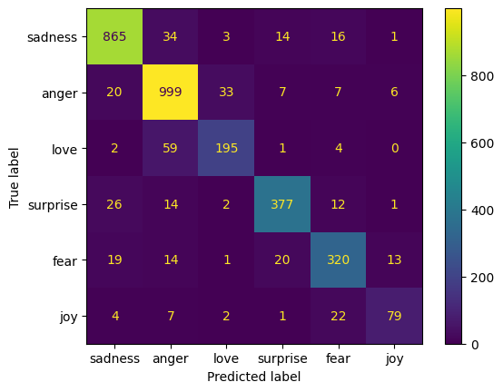

```python
cm = confusion_matrix(y_test, y_pred_lr)  # labels=labels
disp = ConfusionMatrixDisplay(confusion_matrix=cm, display_labels=labels)
disp.plot();
```

```python
# import pandas as pd
# pd.set_option('display.max_rows', 500)
# pd.set_option('display.max_columns', 500)
# pd.set_option('display.width', 1000)
for i in range(10):
    print
    sample_text = X_test.sample().values[0]
    print(f"sample_text --> {sample_text}")
    for model_name, model in baseline_models.items():
        print(f"{model_name}: {model.get('labels')[model.get('trained_pipeline_model').predict([sample_text])[0]]}")
    print()
```

```
sample_text --> i know later when i read this ill feel regretful that ive posted such thing and ill be mad at my self
logistic regression: sadness
random forest: anger
multinomial naive bayes: sadness

sample_text --> i didn t need to mention our difference but i was feeling very vulnerable because of the differences and was having a bit of fear that in someway i am doing something wrong
logistic regression: fear
random forest: sadness
multinomial naive bayes: fear

sample_text --> im used to being up and around until the wee hours of the morning after changeling so anyone is feeling sociable give me a call im me or stop by
logistic regression: joy
random forest: joy
multinomial naive bayes: sadness

sample_text --> i am so sorry you are feeling so sad
logistic regression: sadness
random forest: sadness
multinomial naive bayes: sadness

sample_text --> i am at a point where i dread anyone asking me for anything because i feel like it is just one more opportunity for me to fail at something and that is a very horrible place for me to be
logistic regression: sadness
random forest: sadness
multinomial naive bayes: sadness

sample_text --> i feel for you you guys who been insulted ill treated lathi charged at the grounds
logistic regression: anger
random forest: anger
multinomial naive bayes: anger

sample_text --> i really feel like i have a lot to offer in this area i would like to focus on troubled teenagers
logistic regression: sadness
random forest: sadness
multinomial naive bayes: sadness

sample_text --> i found myself feeling jealous though
logistic regression: anger
random forest: anger
multinomial naive bayes: anger

sample_text --> i already feel sleep deprived and short on time but if i really want to become a person that i can be proud of i need to start investing and stop paying the minimum amount on my credit card
logistic regression: sadness
random forest: sadness
multinomial naive bayes: sadness

sample_text --> im not going to fix things with ml either by feeling awkward and frustrated and annoyed at some things she does
logistic regression: anger
random forest: anger
multinomial naive bayes: anger
```

Looking at the above, the performance of the model while decent, can definitely be improved. In addition, we still need to observe the bias-variance tradeoff and take appropriate actions to manage that. However, as this project has a tight timeline of 10 days, I will use this trained model, which has decent performance to move on to other project components and route back here later.

# 8. Save the Trained Model and Class Labels

- Logistic Regression is the higest performing model and I select it.

```python
tuned_models = baseline_models  # this line is to avoid changing the code below, since this time I did not do hyperparameter tuning in favour of using better training data.
```

```python
import joblib
cwd = Path.cwd()
trained_model_path = cwd / 'model'
trained_model_filename = "text_emotion.pkl"
trained_model_path_file = trained_model_path / trained_model_filename

selected_model = 'logistic regression'
pipeline_file = open(trained_model_path_file, "wb")
joblib.dump(tuned_models.get('logistic regression').get('trained_pipeline_model'), pipeline_file)
pipeline_file.close()
```

```python
labels_filename = 'labels.txt'
labels_path_file = trained_model_path / labels_filename

labels = ''
for k, v in tuned_models.get('logistic regression').get('labels').items():
    labels += f"{k}:{v}\n"
with open(labels_path_file, 'w') as output:
    output.write(labels)
print(labels)
```

```
0:sadness
3:anger
2:love
5:surprise
4:fear
1:joy
```

# 9. Load the Trained Model and predict

```python
import joblib

# print(trained_model_path_file, '\n')

model = joblib.load(trained_model_path_file)

with open(labels_path_file, 'r') as f:
    content = f.readlines()

labels = {int(line.split(':')[0]):line.split(':')[1].strip()  for line in content}
print(labels, '\n')

sample_text = "I've been waiting so long for this day, finally, it's here!"
pred = model.predict([sample_text])[0]
print(f"sample text: {sample_text}")
print(f"predicted emotion: {labels[pred]}")
```

```
{0: 'sadness', 3: 'anger', 2: 'love', 5: 'surprise', 4: 'fear', 1: 'joy'}

sample text: I've been waiting so long for this day, finally, it's here!
predicted emotion: joy
```

# 10 BentoML Model Store

- https://docs.bentoml.org/en/latest/concepts/model.html

### 10.1 Save to BentoML Model Store

```python
acc = tuned_models.get('logistic regression').get('score')
model_created ='2023-10-22_2023'

import bentoml
saved_bentoml_model = bentoml.sklearn.save_model("emotion_detection_lr",  # Model name in Local BentoML Model Store
                                                 model,  # the trained sklearn model
                                                 labels={    # User-defined labels for managing models in BentoCloud or Yatai
                                                     "owner": "richard chai",
                                                     "stage": "dev",
                                                 },
                                                 metadata={  # User-defined additional metadata
                                                     "acc": acc,
                                                     "model_created": model_created,
                                                     "dataset_name" : "dair-ai_emotion"
                                                 },
                                                 custom_objects={  # Save additional user-defined Python objects
                                                     "class_labels_d": labels_d}
                                                )

saved_bentoml_model
```

```
Model(tag="emotion_detection_lr:m4ksgtdqxgjhrxcg", path="D:\bentoml\models\emotion_detection_lr\m4ksgtdqxgjhrxcg\")
```

To view if it is stored: $> bentoml models list

### 10.2 Load Model from BentoML Model Store to view model info

```python
tag = bentoml.models.get("emotion_detection_lr:latest")
print(tag.info.labels)
print(tag.info.metadata)
print(tag.custom_objects)
```

```
{'owner': 'richard chai', 'stage': 'dev'}
{'acc': 0.8859375, 'model_created': '2023-10-22_2023', 'dataset_name': 'dair-ai_emotion'}
{'class_labels_d': {0: 'sadness', 3: 'anger', 2: 'love', 5: 'surprise', 4: 'fear', 1: 'joy'}}
```

### 10.3 Load Model from BentoML Model Store to use native methods e.g. predict()

```python
import bentoml
tag = bentoml.models.get("emotion_detection_lr:latest")
class_labels = tag.custom_objects.get('class_labels_d')

emotion_detector = bentoml.sklearn.load_model("emotion_detection_lr:latest")
```

```python
sample_text = ["I was afraid.", "how to I turn on the light?", "This burger is super delicious!"]
predicted_classes = emotion_detector.predict(sample_text)
# print(pred)
for txt, pred_class in zip(sample_text, predicted_classes):
    print(f"sample_text: {txt}")
    print(f"predicted class: {pred_class} --> Emotion Label: '{class_labels.get(pred_class)}'\n")

print("This training dataset does not have a class label for 'neutral', hence it tends to be clumped together with 'joy'")
print("The second sample_text, without further context, should be 'neutral'.")
print("This is something that can be improved on in a future iteration.")
```

```
sample_text: I was afraid.
predicted class: 4 --> Emotion Label: 'fear'

sample_text: how to I turn on the light?
predicted class: 1 --> Emotion Label: 'joy'

sample_text: This burger is super delicious!
predicted class: 1 --> Emotion Label: 'joy'

This training dataset does not have a class label for 'neutral', hence it tends to be clumped together with 'joy'
The second sample_text, without further context, should be 'neutral'.
This is something that can be improved on in a future iteration.
```

bentoml doc lists the below method, but the above cell seems to work fine without using the below code: import bentoml from sklearn.base import BaseEstimator model: BaseEstimator = bentoml.sklearn.load_model("iris_clf:latest")

# 11. BentoML Create API Service

> **Check the performance of the DistilBert model first before deciding whether to create an API Service using this Logistic Regression Model or the DistilBert model**

# =================================

### 11.1 Create BentoML Model as Runner

- Runners are special objects of BentoML that are optimized to use system resources in the most efficient way possible based on their framework.
- Runners are the core components of the APIs
- https://docs.bentoml.org/en/latest/concepts/runner.html

```python
import bentoml

tag = bentoml.models.get("emotion_detection_lr:latest")
emotion_detection_lr_clf_runner = tag.to_runner()
emotion_detection_lr_clf_runner
```

```
Runner(name='emotion_detection_lr', models=[Model(tag="emotion_detection_lr:m4ksgtdqxgjhrxcg", path="D:\bentoml\models\emotion_detection_lr\m4ksgtdqxgjhrxcg")], resource_config=None, runnable_class=<class 'bentoml._internal.frameworks.sklearn.get_runnable.<locals>.SklearnRunnable'>, embedded=False, …
```

### 11.2 Create the BentoML API Service

- https://docs.bentoml.org/en/latest/concepts/service.html
  - Inference APIs define how the service functionality can be called remotely. A service can have one or more APIs. An API consists of its input/output specs and a callback function. read the docs
- I think if I have 2 apis, for example, one for predict, one for classification, it can be done inside one service.py by creating two @svc.api functions.

##### 11.2.1 Create Service.py

# save the code in this cell to "service.py" import bentoml import numpy as np from bentoml.io import NumpyNdarray, Text tag = bentoml.models.get("emotion_detection_lr:latest") class_labels_d = tag.custom_objects.get('class_labels_d') # create a bentoml runner from a stored bentoml model # emotion_detection_lr_clf_runner = bentoml.models.get("emotion_detection_lr:latest").to_runner() emotion_detection_lr_clf_runner = tag.to_runner() # Create a BentoML Service object # The service name will become the name of the Bento. svc = bentoml.Service("emotion_detection_lr_classifier", runners=[emotion_detection_lr_clf_runner]) @svc.api(input=Text(), output=Text()) def classifyemotion(input_text: str) -> str: # this function name, 'classify' will be transformed into the HTTP endpoint /classify # but it can also be customised, see: https://docs.bentoml.org/en/latest/concepts/service.html # e.g. in the @svc.api decorator, adddir # route="/v2/models/my_model/versions/v0/infer", # print('\n\n') # print(type(input_text), input_text) # print('\n\n') class_num = emotion_detection_lr_clf_runner.predict.run([input_text])[0] class_lbl = class_labels_d.get(class_num) # print('\n\n') # print(type(class_lbl), ' -- ', class_lbl) # print('\n\n') # return "world says hello" return class_lbl

##### 11.2.2 Start the Endpoint

# at cmdline run the following to get the endpoint up $> bentoml serve service.py:svc --reload # svc is the var that was declared in service.py (above) # if you used another var name, then the above cmd line code needs to reflect it # The --reload tags ensures that BentoML detects changes made to your script without needing to restart the server. # once the service starts: http://localhost:3000/ to see the API Docs # test with curl command: curl -X POST -H "accept: text/plain" -H "content-type: text/plain" --data "who are you?" http://127.0.0.1:3000/classifyemotion

##### 11.2.3 Test the Endpoint with Curl

```python
!curl -X POST -H "accept: text/plain" -H "content-type: text/plain" --data "what a lousy quiz" http://127.0.0.1:3000/classifyemotion
```

```
sadness
```

```
  % Total    % Received % Xferd  Average Speed   Time    Time     Time  Current
                                 Dload  Upload   Total   Spent    Left  Speed

  0     0    0     0    0     0      0      0 --:--:-- --:--:-- --:--:--     0
100    24    0     7  100    17     55    135 --:--:-- --:--:-- --:--:--   192
```

##### 11.2.4 Test the Endpoint with Python

```python
# get_predictions.py
import json
import requests
import numpy as np

endpoint = "http://127.0.0.1:3000/classifyemotion"

X_data = "Today is a super duper great day!"

response = requests.post(endpoint,
                         headers={
                             "accept": "text/plain",
                             "content-type": "text/plain"
                         },
                         data=X_data)
print('-'*50)
print(type(response))
print(response)
print(response.text)
print()
```

```
--------------------------------------------------
<class 'requests.models.Response'>
<Response [200]>
joy
```

# 12. Build a Bento

- https://towardsdatascience.com/comprehensive-guide-to-deploying-any-ml-model-as-apis-with-python-and-aws-lambda-b441d257f1ec
- Bento is a term introduced by BentoML that refers to an archive that contains everything needed to make our API work — in a unified format
- Inside a Bento, there will be instructions on building a Docker image and the dependencies of our API model
- https://docs.bentoml.org/en/latest/concepts/bento.html

### 12.1 Create `bentofile.yaml`

- https://docs.bentoml.org/en/latest/concepts/bento.html
- We start building the Bento by creating a bentofile.yaml file (the service name should be the same as our service.py script) and **in the same directory level as our scripts.** It will look like below:

```python
service: "service.py:svc"  # Same as the argument passed to `bentoml serve`
labels:
    owner: Richard Chai
    stage: dev
include:
- "*.py"
python:
    packages:  # Additional pip packages required by the service
    - bentoml==1.1.6
    - numpy==1.26.0
    - pandas==2.1.1
    - scikit_learn==1.3.1
```

### 12.2 Run the next command to build the Bento

$> bentoml build if successfull, the following will appear:

[figure not shown]

Successfully built Bento(tag="emotion_detection_lr_classifier:2d37jtlqxg6uzxcg"). Possible next steps: * Containerize your Bento with `bentoml containerize`: $ bentoml containerize emotion_detection_lr_classifier:2d37jtlqxg6uzxcg [or bentoml build --containerize] * Push to BentoCloud with `bentoml push`: $ bentoml push emotion_detection_lr_classifier:2d37jtlqxg6uzxcg [or bentoml build --push]

### 12.3 Run the next command to view the Bento just built and others available

$> bentoml list

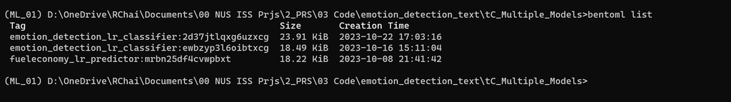

# 13. Create Docker Image using Bento

$ bentoml containerize emotion_detection_lr_classifier:2d37jtlqxg6uzxcg if successful, the following will appear:

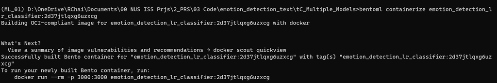

To run your newly built Bento container, run: docker run --rm -p 3000:3000 emotion_detection_lr_classifier:2d37jtlqxg6uzxcg

# 13.1 Create Docker container and Test it

$> docker run --rm -p 3000:3000 emotion_detection_lr_classifier:2d37jtlqxg6uzxcg add -d to run docker in detach mode and see other commands to stop the container https://docs.docker.com/language/golang/run-containers/ $> docker run -d --rm -p 3000:3000 emotion_detection_lr_classifier:2d37jtlqxg6uzxcg

### 13.1.2 Get Predictions from the Running Docker Container using curl

curl -X POST -H "accept: text/plain" -H "content-type: text/plain" --data "who are you?" http://127.0.0.1:3000/classifyemotion

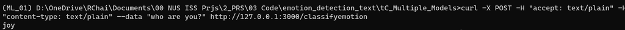

##### Note that the training dataset does not contain the emotion "neutral", instead if a text looks like it should be "neutral",

it will be classified as "joy", i.e. neural is not a negative sentiment, neither is it positive, but let's put it as positive since we don't have a neutral emotion to put it in.

### 13.1.3 Get Predictions from the Running Docker Container using Python code

```python
# get_predictions.py
import json
import requests
import numpy as np

endpoint = "http://127.0.0.1:3000/classifyemotion"

X_data = "Today is a super duper great day!"

response = requests.post(endpoint,
                         headers={
                             "accept": "text/plain",
                             "content-type": "text/plain"
                         },
                         data=X_data)
print('-'*50)
print(type(response))
print(response)
print(response.text)
print()
```

```
--------------------------------------------------
<class 'requests.models.Response'>
<Response [200]>
joy
```